# Nina Briantseva — Portfolio

0%

[interactive chart not shown]

DESIGN portfolio

Product-focused UX/UI designer  
based in Tallinn.

⌄

Selected work

[figure not shown]

Pleasant pain

UIBrand identityLogo designUX2025

[figure not shown]

Argo e-commerce

UIUXGraphic2024

[figure not shown]

Working horse extension

UX/UI2025–2026

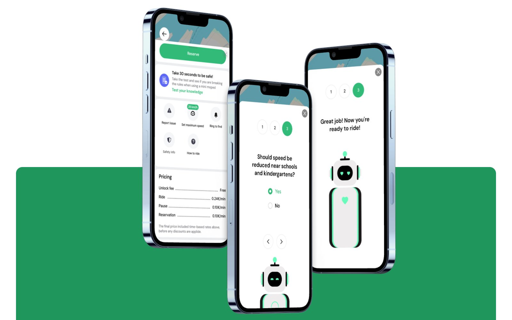

Bolt speculative project

Speculative2025

About

Product-minded UX Designer with a foundation in professional storytelling and journalism. I specialize in transforming complex information into intuitive user flows. My background in social sciences and media allows me to conduct deep qualitative research and advocate for the user.

Figma UX Research Wireframing Prototyping Design Systems Illustrator After Effects Spline

Jul 2025 – Feb 2026

ABZ Agency

Product Designer

End-to-end user flows, complex UX patterns, reusable UI components and design system.

Mar 2024 – Jul 2025

Kalina Design OÜ

UX/UI, Graphic Designer

Wireframing, prototyping, user flows, logo and poster design.

Oct – Dec 2023

SPRYGLE AI

UX Design Intern

Wireframes, mockups and user personas for an AI-focused product.

Jun 2020 – Jul 2025

Delfi Meedia

Journalist, Digital Web Editor

Qualitative research, content hierarchy and storytelling.

Jan 2026

Projector Institute

Growth Design Course

Product metrics, onboarding design, retention and monetization strategies.

Jul 2023 – Feb 2024

Google

UX Design Specialization

Wireframes, prototypes, UX research in Figma.

Sep – Mar 2024

SDA Eesti

UX Design

UX design foundations and qualitative research methods.

Dec 2021 – Dec 2022

"Contented" Design School

Graphic Design

Identity design, package design, key visuals.

Sep 2019 – Jul 2021

University of Tartu

MA Social Sciences

Qualitative research, social science methodology.